# S2.3: dove nascono i trascritti dentro le cellule simulate, come si spostano, e la variabilità fine dei quadratini somiglia a quella vera?

geo_spatialtrans, report di step (protocollo v2)

Published

November 6, 2026

# In breve: dove nascono i trascritti dentro le cellule simulate, come si spostano, e la variabilità fine dei quadratini somiglia a quella vera?

**A cosa serviva.** Con questo step il simulatore mette ogni trascritto in un punto preciso della sua cellula, con il nucleo più o meno denso del citoplasma secondo il tessuto, e poi lo sposta come abbiamo misurato ai bordi dei vetrini veri. Aggiunge anche una variazione fine della densità, su 1-2 µm, che i vetrini veri mostrano dentro i nuclei: l’abbiamo tarata sui nuclei veri. Poi abbiamo confrontato le 30 aree simulate con le stesse aree vere, e misurato il vetro vicino al tessuto sulle cinque sezioni intere.

**Cosa abbiamo trovato.**

1. **La funzione fa quello che deve: ogni trascritto resta contato, nasce dove deve e si sposta con la regola misurata.**
   - Tutti i test passano e ogni errore inserito apposta nel codice viene trovato; il risultato è identico rifatto da zero con un altro numero di processi.
   - Il revisore del codice ha trovato un difetto piccolo: una striscia larga un decimo di micron sul lato delle aree simulate veniva trattata come bordo del tessuto. L’ho corretto e rifatto tutto; i risultati non cambiano fino alla quarta cifra.
2. **Dentro i nuclei la variazione fine tarata funziona; fuori dai nuclei i quadratini veri variano molto più dei simulati.**
   - Nel nucleo il simulato torna sul vero in tutti e sei i tessuti (stime entro il 4 %; in quattro tessuti l’incertezza fra le aree è più larga del margine che avevamo fissato).
   - Nella corona attorno al nucleo e nello spazio senza cellule i veri variano da una volta e mezza a quasi tre volte più dei simulati, nell’intestino, nel tumore del colon, nello stroma e nel cervello; nel linfonodo poco di più, nel cuore come il simulato.
   - Fuori dai nuclei i quadratini veri si somigliano anche a 4 µm di distanza: è una struttura più larga di quella che una variazione di 1-2 µm può dare.
3. **Sulle 30 aree simulate il contrasto fra nucleo e citoplasma è giusto in 5 tessuti su 6 e i bordi dei lumi dell’intestino tornano.**
   - Lontano dal bordo del nucleo il contrasto è giusto nell’intestino, nello stroma e nel cervello; nel cuore resta sbagliato, come sapevamo.
   - Dentro i nuclei simulati la variabilità sembra più bassa del vero, ma solo perché i nuclei simulati hanno meno trascritti per quadratino (da due terzi a nove decimi del vero). Tenendone conto, la variazione fine torna entro un ventesimo in quattro tessuti, e un sesto o un quarto più alta nello stroma e nel tumore.
   - Nel cervello i «lumi» delle aree simulate sono in realtà tessuto pallido che la maschera dello Step 1 perde: lì il confronto sui lumi non vale.
4. **Il calo dell’RNA dal nucleo alla periferia del cervello non si spiega solo con il nucleo più denso.**
   - Se il nucleo simulato avesse la stessa densità del citoplasma, il calo simulato nel cervello e nel cuore sarebbe molto più debole: la densità del nucleo ne spiega una parte.
   - Ma anche con il nucleo più denso il calo vero nel cervello è più ripido del simulato: di un quinto sulle aree simulate e di oltre un quarto quando simuliamo sui nuclei veri.
   - Nel cuore il risultato è incerto; nello stroma il simulato cala meno perché non ha spazio senza cellule.
5. **Sul vetro vicino al tessuto c’è più RNA di quanto il modello preveda: nel tumore del colon circa il doppio, nel cervello circa una volta e mezza, fino a 256 µm dal bordo.**
   - Lo spiega meglio, in tutte e cinque le sezioni, una seconda coda molto lunga dello spostamento: da mezzo a cinque trascritti su cento che finiscono a 80-500 µm, più che un fondo in più sul solo vetro.
   - La correzione della sorgente che avevo scritto nella pre-registrazione gonfia invece la previsione del tessuto del 4-12 %, e nell’intestino dà un adattamento assurdo.

**Cosa devi decidere.**

1. **Fuori dai nuclei teniamo una sola variazione fine, dichiariamo il limite e studiamo quella struttura in uno step dedicato? Consiglio di sì.**
   - Non sappiamo ancora su che scala vive: va misurata la somiglianza fra quadratini fino a 10-20 µm, nel citoplasma e nello spazio senza cellule.
   - Alternativa: aggiungere ora una seconda variazione, solo fuori dai nuclei, tarata sulla corona. Conseguenza: un pezzo nuovo del modello costruito senza conoscere la scala, con il rischio di imitare la cosa sbagliata.
   - Alternativa: tarare una sola variazione su tutte le zone insieme, come avevamo deciso all’inizio. Conseguenza: i nuclei diventerebbero troppo variabili e la corona resterebbe comunque sotto il vero.
2. **Per la seconda coda usiamo i valori stimati senza la correzione della sorgente? Consiglio di sì.**
   - Senza la correzione il tessuto previsto torna sull’osservato entro un punto e mezzo percentuale e i valori sono coerenti fra le sezioni (pochi trascritti su cento, a centinaia di µm).
   - Con la correzione, come avevo scritto, il tessuto previsto è gonfiato e nell’intestino la «coda» diventa un sesto dei trascritti spostati di 5 µm, che cambierebbe la sfocatura dei bordi misurata.
   - La seconda coda entrerà nel simulatore quando scriveremo la cattura; la forma l’hanno scelta i dati con la regola che avevi approvato.
3. **Chiudiamo lo step anche se il ricalcolo indipendente non è passato come scritto in due punti? Consiglio di sì.**
   - Avevo scritto che, quando un quadratino è alla stessa distanza da due nuclei, vince il nucleo con il numero più basso; il codice, come nei passi precedenti, usa un’altra regola. Con la regola del codice i revisori ritrovano i numeri identici; con quella scritta cambiano al più di tre centesimi, molto sotto le soglie.
   - La simulazione indipendente dà una variabilità più alta di uno o due centesimi: il nostro banco liscia un poco la variazione fine. Nessun esito cambia.
   - Alternativa: riscrivere le due regole e rifare i controlli; nessun numero cambierebbe.

**Comunque**: la seconda coda entra quando scriveremo la cattura; la differenza di trascritti nei nuclei simulati si guarda con la revisione della densità dei preset; il calo radiale del cervello resta una questione aperta, con la misura di oggi; il tessuto pallido del cervello che lo Step 1 perde va nel lavoro sulle regioni. Lo step sulle aree di riferimento sovrapposte resta da fare prima del confronto finale con i tessuti veri.

Appena decidi questi 3 punti, lo step è chiuso.

**Sui tempi di calcolo.** Misurati da me, sul server condiviso, un processo per area: la funzione impiega 10-15 s per un’area di 1 mm² del cuore e 43-62 s per il tumore del colon, entro i 5 minuti del documento di progetto. Il calcolo dello step (banco, pannello, sezioni, controlli) ha girato con al più 6 processi per lavoro.

# Decisioni e verifiche di Luca

- «sessione geo_spatialtrans, step S2.3» (chat, 2026-11-06): apertura di S2.3; letta come la scelta di fare S2.3 prima dello step sulle aree sovrapposte (DEC-048 punto 2).
- «Tutto ciò che è assegnato (Recommended)» (chat, 2026-11-06): perimetro dello step.
- «Ok, come proposte (Recommended)» (chat, 2026-11-06): previsioni P-1…P-9, soglie, regole, correzione C-1.
- «si a tutto. Chiudi» (chat, 2026-11-06): risposta alle tre decisioni del riassunto, lette come le tre raccomandazioni: una sola variazione fine, limite dichiarato fuori dai nuclei e step dedicato (DEC-050); seconda coda con i valori senza correzioni (DEC-051); chiusura con G-5 fallito come scritto (DEC-052).

# Dubbi rinviati

| cosa | perché | cosa serve per chiuderlo | step destinatario | voce di BACKLOG |
| --- | --- | --- | --- | --- |
| variabilità fuori dal nucleo (corona, spazio senza cellule) 1.6-2.7 volte la simulata, correlata a 4 µm | una sola variazione di 1-2 µm non la descrive | misura della somiglianza fra quadratini fino a 10-20 µm fuori dai nuclei; modello dopo la decisione di Luca | da assegnare (decisione 1) | BL-220 |
| seconda coda lunga dello spostamento (R-2) | è uno strato del passo di cattura | implementazione con i valori scelti da Luca; margine di 280 µm contro ℓ₂ fino a 518 µm | S2.4 | BL-221 |
| nuclei simulati con meno trascritti per quadratino (0.63-0.92 del vero) | densità dei preset e fattore di profondità | revisione delle densità dei preset | con BL-167, BL-213, BL-218 | BL-222 |
| calo radiale dell’RNA nel citoplasma del cervello (e stroma, cuore) | oltre il contrasto del nucleo | misura del profilo radiale nel citoplasma e opzione del gradiente | da assegnare | BL-087 |
| «lumi» del cervello che sono tessuto pallido | maschera delle regioni dello Step 1 (R2) | maschera con il tessuto pallido | da assegnare | BL-085 |
| il banco liscia la variazione fine (1-2 %) e minimi di R-1 sul bordo della griglia in L | interpolazione del prototipo; griglia fine | ritaratura con la funzione in R o con integrazione esatta; griglia allargata | S2.5 (verifica) | BL-223 |

# Cancelli, previsioni e controprova

Tabelle in `results/S2.3/`: `S2.3_R1_choice.csv`, `S2.3_R1_loss.csv`, `S2.3_P123_bench.csv`, `S2.3_bench_verify_roi.csv`, `S2.3_P4_glass.csv`, `S2.3_P4_verdicts.csv`, `S2.3_R2_fits.csv`, `S2.3_P5_P9.csv`, `S2.3_CP.csv`, `S2.3_panel_roi.csv`; post hoc `S2.3_P4_glass_PH1_nocorr.csv`, `S2.3_R2_fits_PH1_nocorr.csv`, `S2.3_PH2_depth.csv`, `S2.3_PH3_lumens.csv`, `S2.3_PH4_radial.csv`; tempi `S2.3_timing.csv`. Le aree dello stesso tessuto si sovrappongono (BL-215): gli intervalli fra aree sono ottimistici.

**Regola R-1** (taratura del campo sul nucleo), decisione tecnica in S2.3: campo di variabilità fine tarato sul nucleo (DEC-049):

| tessuto | s² | L (µm) | q nucleo (griglia) | e1 nucleo (griglia) |
| --- | --- | --- | --- | --- |
| intestino | 0.5 | 0.6375 | 0.997 | −0.011 |
| tumore | 0.5 | 0.5 | 1.036 | −0.026 |
| stroma | 0.354 | 0.85 | 1.035 | +0.040 |
| linfonodo | 0.297 | 1.275 | 1.009 | +0.055 |
| cervello | 0.0743 | 1.275 | 1.012 | +0.054 |
| cuore | 0.841 | 0.885 | 1.021 | −0.022 |

**Cancelli.**

| id | esito | dettaglio |
| --- | --- | --- |
| G-1 | superato | R 39/39 (`S2.3_G1_tests.txt`, dopo la correzione DSC-1, con i test nuovi h3 e a7), Python 9/9 (`S2.3_G1_pytests.txt`), mutanti 11/11 rilevati (`S2.3_mutants.txt`). Nella parte (e) la media della funzi… |
| G-2 | superato | main 60/60, campo spento 30/30, sfocatura stretta 30/30, r = 1 30/30: conservazione per cellula, per gene (dopo DSC-3) e totale, nessun NA, ogni trascritto nella griglia o fra i persi; quota nel nucle… |
| G-3 | superato | banco: preparazione 30/30 aree identiche in tutti i campi, verifica 30/30 file identici; pannello: 60/60 file dei conteggi con md5 identico, 60/60 statistiche identiche (`S2.3_G3.txt`; 3 processi inve… |
| G-4 | superato | (a) md5 dei 479 file letti identici prima e dopo (`S2.3_md5_before.txt`, `S2.3_md5_after.txt`, 0 righe diverse); (b) batterie di S2.1 21/21 e S2.2 36/36; (c) il banco ritrova S2.0 PH-2 esattamente: r,… |
| G-5 | **fallito come scritto** in (a) e (b) | vedi «Revisione avversariale»: (a) con la regola dei pareggi scritta nel cancello (etichetta più bassa) i numeri non tornano entro 1e-9; con la regola del codice (indice della trasformata di scipy, co… |

**Previsioni del banco (P-1…P-3)**, verifica con 5 repliche nuove, stima ± 2 errori standard fra le aree (`S2.3_P123_bench.csv`):

| tessuto | ψ nucleo | ψ corona | ψ spazio senza cellule | ρ1 nucleo / corona / spazio | ρ2 nucleo / corona / spazio |
| --- | --- | --- | --- | --- | --- |
| intestino | 0.992 [0.893, 1.092] indeterminata | 0.537 smentita | 0.435 smentita | conf. / smentita / smentita | conf. / smentita / indet. |
| tumore | 1.031 [0.933, 1.128] indeterminata | 0.570 smentita | 0.365 smentita | conf. / smentita / smentita | smentita / smentita / smentita |
| stroma | 1.034 [0.961, 1.107] indeterminata | 0.624 smentita | 0.585 smentita | conf. / smentita / smentita | indet. / smentita / smentita |
| linfonodo | 1.012 [0.973, 1.051] confermata | 0.835 smentita | 0.834 smentita (2 aree) | conf. / conf. / conf. | smentita / conf. / conf. |
| cervello | 1.019 [0.979, 1.059] confermata | 0.392 smentita | 0.438 smentita | conf. / smentita / smentita | conf. / smentita / smentita |
| cuore | 1.013 [0.842, 1.184] indeterminata | 1.150 [1.077, 1.223] indeterminata | 1.087 [0.967, 1.207] indeterminata | conf. / conf. / conf. | indet. / conf. / indet. |

P-1 (previsto: nucleo confermata in 6 su 6; corona e spazio senza cellule smentite per difetto in almeno 3 tessuti): nucleo 2 confermate (linfonodo, cervello) e 4 indeterminate, con stime 0.99-1.03 ma intervallo fra aree più largo del margine (la variabilità fra aree vere scritta nella riga di P-1 lo lasciava prevedere); corona e spazio senza cellule smentite per difetto in 5 tessuti su 6, tutti salvo il cuore. Fuori dal nucleo i simulati hanno anche meno correlazione a 2 e 4 µm (ρ1 da −0.15 a −0.33, ρ2 da −0.10 a −0.37 nei quattro tessuti densi). **R-4 scatta** (smentita fuori dal nucleo in almeno 2 tessuti): decisione di Luca.

**P-4, vetro vicino al tessuto** (come scritto, dopo la correzione D-glass-1; `S2.3_P4_verdicts.csv`): tumore del colon smentita per eccesso in 4 fasce su 4 (1.57, 1.87, 2.29, 1.93); cervello smentita per eccesso a 64-128 e 128-256 µm (1.51, 1.44), indeterminata a 16-64 µm; intestino confermata a 16-128 µm (0.87, 0.87, 1.18), indeterminata a 128-256 µm (1.17 [1.10, 1.26]); linfonodo confermata in 3 fasce, indeterminata a 32-64 µm (0.86); cuore indeterminata in 4 fasce su 4. **R-2 scatta** (tumore 3 fasce, cervello 2 fasce fra 32 e 256 µm). Vince la seconda coda (A) in 5 sezioni su 5, sia come scritto sia senza le correzioni (PH-1). Parametri come scritto: intestino w₂ 0.167, ℓ₂ 5.06 µm (non è una coda: l’adattamento compensa la sorgente gonfiata, PH-1); tumore e stroma 0.0180, 478 µm; linfonodo 0.0032, 518 µm; cervello 0.0295, 195 µm; cuore 0.0333, 90.8 µm. Senza le correzioni: intestino 0.0059, 347 µm; tumore e stroma 0.0211, 455 µm; linfonodo 0.0048, 509 µm; cervello 0.0356, 183 µm; cuore 0.0497, 84.3 µm (`S2.3_R2_fits*.csv`). Quali valori adottare: decisione di Luca.

**Previsioni del pannello (P-5…P-9)** (`S2.3_P5_P9.csv`):

| tessuto | contrasto (P-5) | controllo interno (P-6) | calo radiale R (P-7) | ψ nucleo (P-8) | ψ corona (P-8) | lumi 2-4 / 4-8 µm (P-9) |
| --- | --- | --- | --- | --- | --- | --- |
| intestino | 1.018 confermata | 1.003 confermata | 1.012 confermata | 0.746 smentita | 0.570 smentita | 0.967 / 1.110 confermate |
| tumore | 1.054 confermata | 1.120 indeterminata | 0.881 indeterminata | 1.114 indeterminata | 0.945 indeterminata | 1.337 / 1.034 indeterminate |
| stroma | 1.017 confermata | 1.013 confermata | 1.338 smentita | 0.920 indeterminata | 0.956 indeterminata | 2 lumi, descrittivo |
| linfonodo | 0.981 confermata | 0.904 indeterminata | 1.178 indeterminata | 0.795 smentita | 1.031 indeterminata | nessun lumo |
| cervello | 0.996 confermata | 0.980 confermata | 1.199 smentita | 0.833 smentita | 0.507 smentita | 0.632 / 0.493 smentite |
| cuore | 1.014 indeterminata | 0.579 smentita | 1.075 indeterminata | 0.803 indeterminata | 1.113 indeterminata | 0.821 / 0.840 indeterminate |

**Controprova** (`S2.3_CP.csv`). CP-1 superata: con il campo spento ψ del nucleo simulato / vero 0.33-0.55, smentito in 6 tessuti su 6. CP-2 superata: con la sola sfocatura stretta la fascia 4-8 µm dei lumi vale 0.03-0.13 del vero, smentita in 4 tessuti su 4. CP-3 superata: con r = 1 il contrasto è smentito in 6 tessuti su 6 (cervello 0.77, cuore 0.58, linfonodo 1.24) e il calo radiale simulato / vero sale a 1.45 nel cervello e 1.52 nel cuore (smentito).

**Tempi** (descrittivi, server condiviso, un processo per area; `S2.3_timing.csv`): la funzione richiede 10-15 s per un’area di 1 mm² del cuore (0.77 milioni di trascritti) e 43-62 s per il tumore del colon (9.6 milioni); persi fuori dall’area al più 2.5 trascritti su 100 000 (linfonodo, 695 su 27.9 milioni in 10 aree).

## Banco: variabilità simulata contro vera per zona della cellula

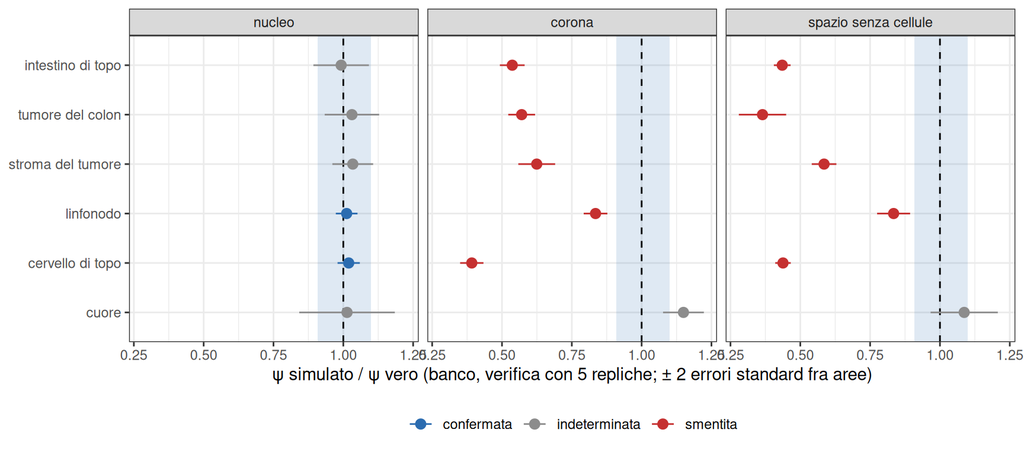

Figure 1

Cosa guardare: nel nucleo, su cui il campo è tarato, le stime stanno sull’1 in tutti i tessuti; nella corona e nello spazio senza cellule i punti stanno fra 0.37 e 0.62 in quattro tessuti densi (la banda azzurra è l’intervallo di rilevanza).

## Vetro vicino al tessuto

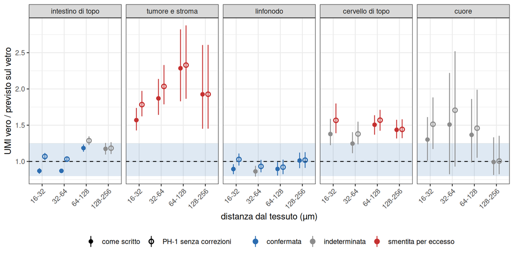

Figure 2

Cosa guardare: nel tumore e nel cervello i punti stanno sopra la banda anche lontano dal tessuto; i cerchi vuoti sono la versione senza le correzioni della sorgente (analisi post hoc PH-1).

Seconda coda (forma vincente in 5 sezioni su 5) nelle due varianti

| variante | sezione | tessuto osservato / previsto | massa w₂ | lunghezza ℓ₂ (µm) |
| --- | --- | --- | --- | --- |
| come scritto | A1 | 0.8979 | 0.1675 | 5.0618 |
| come scritto | A23 | 0.9247 | 0.0180 | 477.8639 |
| come scritto | A4 | 0.9118 | 0.0032 | 517.7451 |
| come scritto | A5 | 0.9612 | 0.0295 | 195.1784 |
| come scritto | A6 | 0.8962 | 0.0333 | 90.7733 |
| senza correzioni (PH-1) | A1 | 1.0144 | 0.0059 | 346.9492 |
| senza correzioni (PH-1) | A23 | 1.0037 | 0.0211 | 455.4515 |
| senza correzioni (PH-1) | A4 | 0.9973 | 0.0048 | 508.8826 |
| senza correzioni (PH-1) | A5 | 1.0042 | 0.0356 | 182.5982 |
| senza correzioni (PH-1) | A6 | 0.9994 | 0.0497 | 84.2575 |

## Pannello: le 30 aree simulate contro le stesse aree vere

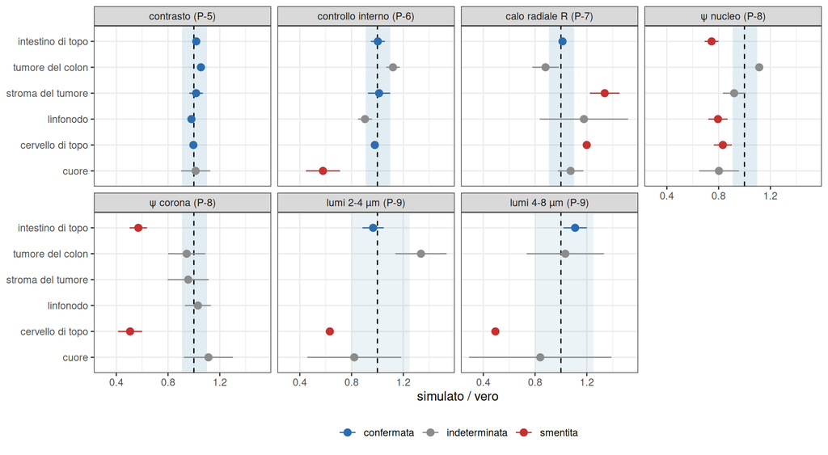

Figure 3

Cosa guardare: il contrasto sta sull’1 in cinque tessuti; ψ del nucleo è sotto il vero dove i nuclei simulati hanno meno trascritti (PH-2); il calo radiale del cervello è più debole nel simulato (R sopra 1).

## Controprova

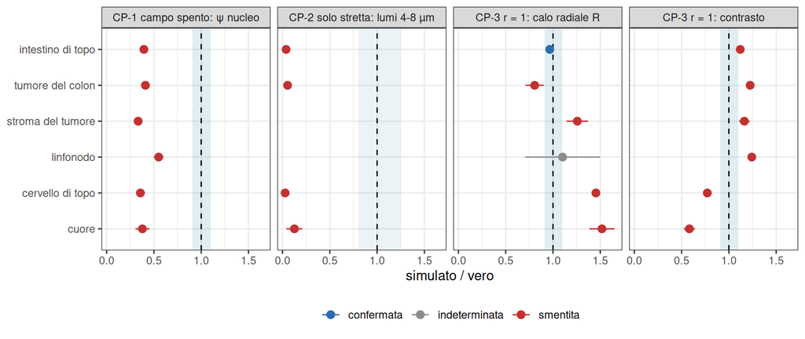

Figure 4

Cosa guardare: togliendo ciascun pezzo del modello la misura che lo riguarda esce dall’intervallo: il pannello vede il campo, la zona di bordo e il rapporto nucleo/citoplasma.

# Analisi post hoc

- **PH-1, vetro senza le correzioni della sorgente** (dopo P-4; `S2.3_P4_glass_PH1_nocorr.csv`). Le due correzioni moltiplicative pre-registrate gonfiano la sorgente: il tessuto previsto supera l’osservato del 4-12 % (osservato / previsto 0.896-0.961), contro 0.997-1.014 senza correzioni; il revisore attribuisce l’effetto alla correzione punto per punto su conteggi rumorosi (disuguaglianza di Jensen) e al pavimento 0.2. Senza correzioni gli esiti di P-4 cambiano in 3 caselle su 20 (intestino 64-128 µm da confermata a indeterminata, 1.29; linfonodo 32-64 µm da indeterminata a confermata; cervello 16-32 µm da indeterminata a smentita) e l’innesco di R-2 resta lo stesso.
- **PH-2, profondità dei nuclei sul pannello** (dopo P-8; `S2.3_PH2_depth.csv`). I quadratini profondi dei nuclei simulati hanno meno UMI dei veri (rapporto 0.63 intestino, 0.92 tumore, 0.79 stroma, 0.63 linfonodo, 0.74 cervello, 0.67 cuore); la varianza in più depurata dalla profondità, (ψ − 1)/m, simulata / vera vale 0.996, 1.26, 1.15, 0.96, 1.05, 1.05. Il campo tarato si trasferisce alla geometria dello Step 1; ψ è più basso perché i nuclei simulati sono meno densi di trascritti (densità dei preset e fattore di profondità, BL-218).
- **PH-3, i lumi dello Step 1 sono vuoti?** (dopo P-9; `S2.3_PH3_lumens.csv`). Dei quadratini delle fasce 2-8 µm dentro i lumi, la maschera H&E di R5 (densità ottica) chiama tessuto il 100 % nel cervello (20 015 su 20 015), il 18.5 % nel cuore, lo 0 % negli altri tessuti. Nel cervello i «lumi» delle regioni dello Step 1 sono tessuto pallido che la maschera di R2 perde (BL-085), non lumi.
- **PH-4, calo radiale sulla geometria vera** (dopo P-7; `S2.3_PH4_radial.csv`). Sul banco (nuclei veri, campo tarato) R simulato / vero vale 1.28 [1.26, 1.31] nel cervello, 1.13 nel cuore e nello stroma, 1.05-1.07 negli altri: lo scarto del cervello non viene dalla geometria dello Step 1, è un calo dell’RNA nel citoplasma oltre il contrasto del nucleo (BL-087).

# Revisione avversariale

Tre revisori indipendenti con codice proprio (`/mnt/micron/geo_spatialtrans/S2.3/review/{numeri,banco,codice}/`).

- **Numeri veri e vetro.** (a) 468 statistiche vere di 6 aree entro 3.9e-15 con la regola dei pareggi del codice; con la regola scritta in G-5 (etichetta più bassa) cambiano 12-2 260 quadratini per area e le statistiche fino a 2.7e-2 relativo (D-ties): errore di pre-registrazione, il testo non descriveva il codice. (c) Primo giro: il modello del vetro applicava in Fourier, sul passo di 2 µm, la gaussiana di 0.7 µm, che lì non è a banda limitata (guadagno a Nyquist 0.35, nucleo discreto con massa negativa, D-glass-1); corretto con un nucleo esatto in spazio reale (sorgente uniforme nel quadratino, arrivo integrato sul quadratino), P-4 e PH-1 rifatti. Secondo giro: con la stessa convenzione il ricalcolo torna entro 2.6e-7 nelle 16 fasce e nel tessuto, intervalli entro 2.6 errori Monte Carlo. La convenzione della sorgente nel quadratino non era scritta (D-conv-source): senza correzioni pesa al più 1.3e-4; con le correzioni fino al 4.3 % e cambia un esito (cervello 16-32 µm). Il pannello legge le maschere alla posizione allineata, scritto solo per il banco (D-convention): deviazione dichiarata.
- **Banco.** R-1 ricalcolata da 1 650 file: stessi vincitori, perdite entro 4.5e-13; P-1…P-3: 54 esiti identici. Simulazione indipendente in un’area del cervello: λ medio 45.042 contro 45.042, 8 statistiche su 9 entro 3 errori Monte Carlo; ψ dello spazio senza cellule +1.6 % (z 3.47; con 20 repliche per parte +0.9 % nello spazio senza cellule e +2.0 % nel nucleo): il prototipo legge la sfocatura per interpolazione bilineare e riduce di circa l’1.7 % la varianza che il campo aggiunge (D-banco-1, misurato in un’area); la funzione in R, che conta esattamente, darà ψ un po’ più alti del banco a parità di s². 5 vincitori su 6 di R-1 sono sul bordo della griglia fine in L (D-banco-2, regola applicata come scritta).
- **Codice e pannello.** 78 parametri della funzione contro le fonti (scarto ≤ 1.2e-15); la funzione rilanciata su due aree ridà i file dei conteggi identici, conservazione esatta per cellula e gene, quota nel nucleo con il campo come attesa (z 1.14 e −1.41), spostamenti conformi. Rilievi: DSC-1, con `frame_open` i sottopixel tagliati dal lato del riquadro (striscia ≤ 0.104 µm) restavano bordo (1 159 nascite su 4.8 milioni in un’area dello stroma): corretto, pannello rifatto (esiti identici alla quarta cifra), test h3 aggiunto; DSC-2 pareggi (come D-ties); DSC-3 G-2 controllava il totale per gene, non i geni uno per uno: aggiunti i persi per gene e il controllo; DSC-4 nascite in sottopixel non di tessuto con d = 0, quindi π = 1, come scritto nel file dello step (il prototipo usa π = 0 lì; π vale 0.97-0.98 a d ≈ 0.25 µm, quindi la scelta della funzione è la più vicina); DSC-5 il margine del campo è gamma a meno di 6.5e-6 (tabella); DSC-6 nome dell’interruttore (`field` contro `intracell_noise` del documento di progetto).

# Deviazioni dichiarate

1. **Correzione C-1** prima del calcolo (taratura sul nucleo), approvata da Luca con le previsioni.
2. **Errore di pre-registrazione nelle correzioni della sorgente di P-4**: il testo diceva che le correzioni riportano il tessuto previsto all’osservato; lo gonfiano invece del 4-12 %. P-4 è giudicata come scritta; PH-1 dà la versione senza correzioni.
3. **Errore di uno strumento corretto** (D-glass-1): gaussiana stretta in Fourier sul passo di 2 µm; P-4, PH-1 e gli adattamenti di R-2 rifatti con il nucleo esatto (uscite vecchie in `results/S2.3/_superseded_fourier/`). La convenzione della sorgente nel quadratino (uniforme per le gaussiane, puntiforme per la coda) non era scritta.
4. **Difetto del codice corretto** (DSC-1, `frame_open`): pannello rifatto in tutte le varianti (uscite vecchie in `/mnt/micron/geo_spatialtrans/S2.3/panel/_superseded_preDSC1/`); G-1, mutanti e G-3 rifatti dopo la correzione.
5. **Regola dei pareggi**: G-5 scriveva «etichetta più bassa»; il codice (come R4 e R6) usa l’indice della trasformata di distanza di scipy. Errore di pre-registrazione.
6. **Pannello: maschere e regioni lette alla posizione allineata** con lo scarto della sezione anche per il lato vero del pannello (scritto solo per il banco).
7. **G-2 per gene** rafforzato dopo la revisione (DSC-3): la funzione ora restituisce anche i persi per gene.
8. **Modifiche durante il calcolo**: `tools/S2_3_common.py` (tabella del campo con le code superiori) è cambiato mentre girava la preparazione del banco, che non usa il campo; il banco grossolano è partito dopo la modifica.

# Cosa è girato

- Commit della pre-registrazione: `4994f45` (cancelli), `2e49c83` (esplorazione e correzione C-1), `7c7ab8e` (ok di Luca); codice e risultati prima della revisione `eb11a03`; correzioni dalla revisione e risultati finali `40db522`; chiusura nei commit successivi.
- Server condiviso con un altro utente (fino a circa 45 processi R suoi); i nostri lavori con al più 6 processi. Tempi non da manoscritto.
- md5: `results/S2.3/S2.3_md5_before.txt`, `S2.3_md5_after.txt` (479 file identici).

```bash
cd ~/2025.geo_spatialtrans
tools/S2.3_md5.sh before
R_LIBS_SITE=/nonexistent R_LIBS_USER=/nonexistent Rscript --vanilla R/testing/test_S2.3.R; .venv/bin/python tools/S2.3_test.py; tools/S2.3_mutants.sh
.venv/bin/python tools/S2.3_real.py /mnt/micron/geo_spatialtrans/S2.3/e2; .venv/bin/python tools/S2.3_E2_summary.py /mnt/micron/geo_spatialtrans/S2.3/e2
B=/mnt/micron/geo_spatialtrans/S2.3/bench; .venv/bin/python tools/S2.3_bench.py prep $B; .venv/bin/python tools/S2.3_select.py combos_coarse $B/combos_coarse.json
.venv/bin/python tools/S2.3_bench.py grid $B $B/combos_coarse.json 0 3; .venv/bin/python tools/S2.3_select.py combos_fine $B $B/combos_fine.json
.venv/bin/python tools/S2.3_bench.py grid $B $B/combos_fine.json 0 3; .venv/bin/python tools/S2.3_select.py choose $B $B/combos_verify.json
.venv/bin/python tools/S2.3_bench.py grid $B $B/combos_verify.json 10 5; .venv/bin/python tools/S2.3_select.py judge $B
.venv/bin/python tools/S2.3_glass.py /mnt/micron/geo_spatialtrans/S2.3/glass; S23_GLASS_NOCORR=1 .venv/bin/python tools/S2.3_glass.py /mnt/micron/geo_spatialtrans/S2.3/glass; .venv/bin/python tools/S2.3_P4_verdicts.py
P=/mnt/micron/geo_spatialtrans/S2.3/panel; for V in main field_off narrow r1; do Rscript --vanilla tools/S2.3_panel.R $V $P 6; .venv/bin/python tools/S2.3_panel_stats.py $P $V; done
.venv/bin/python tools/S2.3_analysis.py $P /mnt/micron/geo_spatialtrans/S2.3/e2; .venv/bin/python tools/S2.3_posthoc.py $B; .venv/bin/python tools/S2.3_ph2_depth.py
tools/S2.3_repro.sh; tools/S2.3_md5.sh after
```

Tempo di place_and_move_transcripts() per area di 1 mm², un processo

| tessuto | trascritti per area (media) | s min | s max | persi (10 aree) | trascritti (10 aree) |
| --- | --- | --- | --- | --- | --- |
| intestino di topo | 4883521.0 | 25.0 | 36.1 | 133 | 48835210 |
| tumore del colon | 9588453.1 | 42.7 | 62.5 | 7 | 95884531 |
| stroma del tumore | 4817479.9 | 24.6 | 31.7 | 1 | 48174799 |
| linfonodo | 2790409.4 | 25.4 | 28.4 | 695 | 27904094 |
| cervello di topo | 8150606.8 | 32.2 | 42.8 | 296 | 81506068 |
| cuore | 766737.7 | 10.3 | 15.1 | 17 | 7667377 |

# Appendice

## Perimetro

Scelto da Luca il 2026-11-06, in chat, all’apertura: «Tutto ciò che è assegnato (Recommended)». Lo step consegna:

1. `place_and_move_transcripts()` in `R/05b3_place_and_move_transcripts.R` (passi 3 e 4 del documento di progetto), con i parametri per tessuto e la batteria `R/testing/test_S2.3.R`;
2. la taratura del campo di variabilità fine (varianza e lunghezza di correlazione per tessuto) sul banco con la geometria vera, contro dispersione e correlazione fra quadratini vicini nel nucleo, nella corona e nello spazio senza cellule (DEC-040 punto 3; BL-207);
3. la controprova del documento di progetto: contrasto nucleo/citoplasma, controllo interno, dispersione e bordi dei buchi interni rifatti sulle 30 aree simulate dello Step 1 con la funzione nuova;
4. il fondo sul vetro vicino al tessuto contro lo spostamento simulato (BL-206);
5. il calo radiale dell’RNA dal nucleo alla periferia nel cervello e nel cuore, come previsione (BL-087; il documento di progetto lascia la misura «allo step che scriverà questa funzione»).

Ordine degli step: DEC-048 lascia a Luca la posizione dello step sulle aree sovrapposte (R7) rispetto a S2.3 e S2.4. Luca ha aperto questo step («sessione geo_spatialtrans, step S2.3», 2026-11-06): R7 viene dopo S2.3. Fuori perimetro: le strisce e la cattura (S2.4); la somma a 8 µm e il pannello completo (S2.5); i sottotipi disposti nello spazio (BL-216).

## Dubbi ricevuti

| voce | cosa | come la tratta S2.3 |
| --- | --- | --- |
| BL-207 | variabilità a 1-2 µm: nullo simulato per corona e spazio senza cellule; origine; nell’intestino bin profondi scelti sulla maschera non allineata; ψ su pochi nuclei | taratura del campo sul banco (regola R-1) con nucleo, corona e spazio senza cellule; bin profondi scelti sulla maschera allineata con lo scarto della sezione; previsioni P-1…P-3. L’origine (biologica … |
| BL-206 | fondo sul vetro vicino al bordo più alto di quello del vetro lontano (intestino, tumore, cervello) | previsione P-4 per fasce di distanza dal tessuto sulle cinque sezioni, contro il modello di spostamento con il fondo del vetro lontano; regola R-2 |
| BL-087 | calo dell’RNA dal nucleo alla periferia in cervello e cuore (R 0.59 e 0.63 contro 0.90 e 0.98 del nullo) | previsione P-7 sulle aree simulate: il rapporto r > 1 di cervello e cuore basta a spiegarlo?; regola R-3 |

## Attese pre-registrate

Commit dei cancelli: `4994f45`. Ok di Luca sulle previsioni, sulle soglie, sulle regole R-1…R-4 e sulla correzione C-1 (taratura sul solo nucleo): 2026-11-06, «Ok, come proposte (Recommended)». Commit: vedi `git log` («S2.3: ok di Luca sulle previsioni»).

Seme di base 20261112; bootstrap B = 2000, seme 20261113. Unità indipendente: l’area (ROI) per il banco e il pannello, 5 per tessuto (le aree dello stesso tessuto si sovrappongono fino al 39 %, BL-215: gli errori standard fra aree sono ottimistici, lo si scrive accanto a ogni esito); la tessera di 300 µm per il fondo sul vetro. Processi: al più 6, letti dal file `WORKERS` all’inizio di ogni fase, con la protezione della temperatura di R5; il server è condiviso (2026-11-06: un’altra utente con circa 45 processi R, carico medio circa 325). Uscite in `/mnt/micron/geo_spatialtrans/S2.3/` (un file per unità, rilanciabile); tabelle in `results/S2.3/`.

### La funzione `place_and_move_transcripts()`

Ingressi: il livello cellulare dello Step 1 (territori, nuclei, regioni, `metadata$pixel_size_um`), la griglia di S2.1 (`build_hd_grid()`), i trascritti per cellula di S2.2 (`simulate_cell_profiles()`), i parametri del tessuto, un seme. Uscita: per ogni terna (quadratino di 2 µm, cellula, gene) il numero di trascritti che vi atterrano; la verità di origine per (quadratino, cellula), con quanti di quei trascritti sono nati nel nucleo; i trascritti persi fuori dall’area simulata, per cellula; i parametri usati. Il gene non entra nella posizione (design sezione 5): le posizioni dei trascritti di una cellula sono estrazioni indipendenti e identiche, assegnate ai trascritti nell’ordine dei geni.

1. **Posizione di nascita.** Densità nel territorio della cellula proporzionale a r nel nucleo e a 1 nel citoplasma (territorio meno nucleo), moltiplicata per il campo F: q(x) ∝ [r 1(x ∈ nucleo) + 1(x ∈ citoplasma)] F(x). Estrazione esatta: si sceglie nucleo o citoplasma con probabilità r A_n / (r A_n + A_c), un punto uniforme nel poligono (triangolazione vincolata di GEOS, triangolo scelto per area, punto uniforme nel triangolo), accettato con probabilità F(x) / F_max della cellula (massimo di F sui sottopixel del riquadro della cellula); si ripete finché la cellula ha i suoi N_c trascritti. A_n e A_c sono le aree esatte dei poligoni.
2. **Campo F** (design sezione 5, DEC-040): sulla sottogriglia di 0.5 µm del riquadro delle regioni, Z = rumore bianco gaussiano convoluto con una gaussiana di deviazione standard L (µm), riportato a varianza 1 con la somma dei quadrati dei pesi discreti; F = quantile della gamma di media 1 e varianza s² in Φ(Z) (copula gaussiana: margine esattamente gamma). F è costante in ogni sottopixel. Con s² = 0, F = 1 (strato spento, `field = FALSE`). Parametri per tessuto: s² e L dalla regola R-1.
3. **Distanza dal bordo** d di un punto di nascita: trasformata di distanza euclidea esatta (`imager::distance_transform`) della maschera del tessuto sulla stessa sottogriglia di 0.5 µm (sottopixel di tessuto se il suo centro cade nelle regioni), letta nel sottopixel del punto. È la definizione con cui S2.0 ha stimato D (prototipo, `tools/S2_0_common.py`, `make_blur`). Il bordo comprende i buchi delle regioni (lumi, vetro dentro l’area). Opzione `frame_open = TRUE`: il riquadro dell’area non conta come bordo (fuori dal riquadro la maschera vale tessuto); serve alle 30 aree dello Step 1, ritagliate da tessuto vero che continua oltre il riquadro.
4. **Spostamento** (regola della zona di bordo, DEC-039): con probabilità w, coda esponenziale: raggio ~ Gamma(forma 2, scala ℓ) (densità nel piano ∝ exp(−r/ℓ), K2 di R5) e angolo uniforme; altrimenti, con probabilità π(d) = exp(−d/D), gaussiana isotropa con deviazione standard σ_e per asse, e con probabilità 1 − π(d) gaussiana con σ_in = 0.7 µm per asse. Parametri della sezione 9 del documento di progetto.
5. **Conteggio.** Il punto di arrivo si assegna al quadratino di 2 µm che lo contiene (riga i = floor((y − y₀)/2), colonna j = floor((x − x₀)/2)); fuori dalla griglia il trascritto è perso. Nessuna cattura, strisce o fondo: sono di S2.4.
6. **Semi**: flussi L’Ecuyer-CMRG per blocco di cellule (come S2.2) e uno per il campo; il risultato non dipende dal numero di processi; lo stato del generatore dell’utente si ripristina all’uscita.

Parametri del tessuto: r, σ_e, D, w, ℓ, σ_in dalla sezione 9 del documento di progetto (B-379…B-394); s² e L da R-1. Il cuore usa i valori mediani delle altre sezioni per lo spostamento (DEC-037).

### Il banco della taratura (geometria vera, modello completo)

È il prototipo di S2.0 usato per l’indice di dispersione, nella versione con i fattori di cattura per riga e colonna (post hoc PH-2 di S2.0: le strisce sono accese e la statistica ne tiene conto) e con i parametri dei bordi corretti (PH-6, `run1_wfix`), con in più il campo F. Per ognuna delle 30 aree vere: nuclei veri e impronte di R4 (nucleo, corona di 8 µm, spazio senza cellule; maschera di consenso in linfonodo e cuore), densità per cellula e dello spazio senza cellule rifinite come in S2.0, r invertito come in S2.0 con la regola C2 (una volta, senza campo, poi fisso), sorgente moltiplicata per F sulla sottogriglia di 0.5 µm, spostamento C2 con lo scarto della sezione, fattori di cattura c della sezione, Poisson. Stessa definizione di F della funzione in R (stessa sottogriglia, stessi parametri); generatore numpy con seme `[20261112, indice dell'area, indice della combinazione, replica]`.

**Statistiche**, stesse funzioni per veri e simulati (`tools/S2.3_stats.py`):

- *gruppi*: **nucleo**, quadratini con il centro a ≥ 1 µm dentro la maschera del nucleo (come S2.0 M3), raggruppati per nucleo; **corona**, quadratini dell’impronta di 8 µm fuori dal nucleo e a ≥ 2 µm dalla sua maschera, raggruppati per cellula; **spazio senza cellule**, quadratini in tessuto (maschera di R5) fuori da ogni impronta e a ≥ 2 µm da essa, raggruppati in blocchi di 16 µm (8 × 8 quadratini della griglia). Un gruppo entra con almeno 4 quadratini e almeno 1 UMI. Le maschere si leggono **allineate** con lo scarto della sezione (BL-207: nell’intestino 2.36 µm; nelle altre sezioni lo scarto di R5, anche se sotto 1 µm), per veri e simulati;
- *ψ* (indice di dispersione, S2.0 M3): per gruppo X² = Σ (y − m)² / m con m = media del gruppo × c / media di c nel gruppo; ψ = Σ X² / Σ (n − 1);
- *ρ1, ρ2* (S2.0 PH-3): correlazione dei residui standardizzati (y − m)/√m fra quadratini dello stesso gruppo a distanza 1 (2 µm) e 2 (4 µm) lungo righe e colonne, media delle due direzioni.

Per ogni area: q_k = ψ_sim / ψ_obs ed e1_k = ρ1_sim − ρ1_obs, e2_k = ρ2_sim − ρ2_obs, per gruppo k ∈ {nucleo, corona, spazio senza cellule}; il simulato è la media delle repliche. Un gruppo k di un’area con meno di 20 gruppi validi esce per quell’area (lo si riporta).

### La controprova sulle aree simulate (pannello) e il fondo sul vetro

**Pannello.** Le 30 aree dello Step 1 (livelli U6 di S1.6, predefinito dei preset), i trascritti per cellula di S2.2 (`S2.2/panel/<A>_<roi>_s<seme>_<vincitore>.rds`, semi 20261108 e 20261109), la griglia di S2.1 (`build_hd_grid()`), la funzione con `frame_open = TRUE`, i parametri del tessuto e il campo di R-1; seme della funzione 20261112 + 1000 k + indice dell’area (k = 0, 1 per i due semi dei profili). A ogni quadratino si aggiunge un fondo di Poisson con il b del tessuto (design D2-10, sezione 9; prototipo dello strato di S2.4, fuori dal pacchetto); nessuna striscia (c = 1). I veri sono le stesse 30 aree: quadratini di Space Ranger con il centro nel riquadro, coordinate x = (colonna − c0) · µm per pixel, y = (riga − r0) · µm per pixel (le stesse dei livelli dello Step 1, S2.1). Per veri e simulati: tessuto = centro del quadratino nelle regioni dello Step 1 (che vengono dalla maschera dell’area vera); fuori i quadratini entro 25 µm dal riquadro. Nuclei: maschere vere (come R4) e nuclei simulati rasterizzati a 0.25 µm; impronte, corona e scarto di 20 µm del controllo come R4 PH-1 (`footprint_labels` di R6). ψ dei veri con i fattori di cattura della sezione (come il banco), dei simulati con c = 1.

Statistiche del pannello, per area, simulato (media dei due semi) diviso vero:

- *contrasto* (statistica di R4 PH-1): densità media nel nucleo / densità media nella corona, divisa per la stessa con la maschera spostata di 20 µm;
- *controllo interno*: la stessa senza i quadratini entro 2 µm dal bordo del nucleo (CP-1 di R5, controllo interno di S2.0);
- *rapporto radiale* R (S1.3c, BL-087): UMI medio dei quadratini di tessuto a 4-8 µm dal nucleo più vicino diviso quello a 0-2 µm (0 dentro il nucleo);
- *ψ del nucleo e della corona* come nel banco;
- *lumi*: buchi delle regioni interamente nel riquadro, di area ≥ 2 500 µm² (la soglia dei lumi di R5); fasce 2-4 e 4-8 µm dentro il lumo dal bordo; valore = UMI medio per quadratino della fascia / UMI medio dei quadratini di tessuto entro 8 µm dal bordo del lumo. Si giudica nei tessuti con almeno 10 lumi sulle 5 aree; altrove è descrittivo.

**Fondo sul vetro vicino al tessuto (BL-206).** Sulle cinque sezioni intere (matrici di R5 `run3/section`, `in_tissue` di Space Ranger, esclusi i 50 quadratini al bordo dell’area di cattura): sorgente stimata sui quadratini di tessuto T = max(u − b, 0), con b il fondo del vetro lontano della sezione (B-342…B-366); previsione P = b + (1 − w)[G(σ_e) ∗ (T π) + G(σ_in) ∗ (T (1 − π))] + w E(ℓ) ∗ T sulla griglia di 2 µm, π dalla distanza dal bordo di `in_tissue`, parametri della sezione 9; due correzioni moltiplicative di T sui quadratini di tessuto (T ← T · (u − b)/(P − b), limitate a [0.2, 5]) perché il tessuto previsto torni a quello osservato. Fasce della distanza dal tessuto 16-32, 32-64, 64-128, 128-256 µm (sotto 16 µm la maschera di Space Ranger non è abbastanza precisa); valore = Σ osservato / Σ previsto nella fascia; incertezza: bootstrap delle tessere di 300 µm.

### Regole di decisione dei dati (scritte prima del calcolo)

**R-1, taratura del campo** (DEC-040 punto 3, con la correzione C-1 sotto). Per tessuto, griglia grossolana L ∈ {0.5, 0.75, 1, 1.5, 2} µm × s² ∈ {0.0625, 0.125, 0.25, 0.5, 1, 2, 4, 8}, 3 repliche per area; perdita Λ(θ) = (media sulle aree di q_nucleo − 1)² + (media sulle aree di e1_nucleo)². Griglia fine attorno al minimo: s² × 2^{−0.5, −0.25, 0, 0.25, 0.5}, L × {0.85, 1, 1.18}. Vince la combinazione con Λ minore fra tutte quelle valutate; poi una verifica con 5 repliche nuove (indici 10-14) sulla combinazione vincente: su quella si giudicano P-1…P-3, nel nucleo come controllo dell’adattamento, nella corona e nello spazio senza cellule come verifica che un campo solo valga per tutto il tessuto. È una decisione tecnica dei dati.

**R-2, fondo vicino al tessuto** (BL-206). Se P-4 è smentita per eccesso in almeno 2 sezioni in almeno 2 delle fasce 32-64, 64-128, 128-256 µm, lo strato del fondo (S2.4) riceve un termine in più. La forma la scelgono i dati, qui, fra due candidate a due parametri, adattate per sezione con la verosimiglianza di Poisson sui quadratini di vetro a 16-500 µm dal tessuto: (A) una seconda coda, massa w₂ e lunghezza ℓ₂, che sposta trascritti dal tessuto; (B) un termine solo sul vetro, b₁ exp(−d/L_b). Vince quella con la somma degli AIC più bassa nel maggior numero di sezioni (pareggio: somma degli AIC). Altrimenti nessun termine in più e BL-206 si chiude come spiegata dallo spostamento.

**R-3, calo radiale** (BL-087). Se P-7 è confermata o indeterminata nel cervello e nel cuore, l’opzione del gradiente radiale resta spenta e BL-087 si chiude come spiegata dal rapporto nucleo/citoplasma. Se è smentita in uno dei due, BL-087 resta aperta con lo scarto misurato.

**R-4, un campo per tutto il tessuto.** Se P-1 è smentita nella corona o nello spazio senza cellule in almeno 2 tessuti, un campo solo non descrive nucleo, corona e spazio senza cellule insieme: lo step non cambia il modello e porta a Luca la scelta (varianza per compartimento o limite dichiarato).

### Cancelli (al massimo 5)

Soglie per i confronti multipli: dove un cancello fa m confronti z, la soglia è quella di Bonferroni per un errore di famiglia di 0.001, |z| < Φ⁻¹(1 − 0.0005/m) (lezione di S2.2, G-2).

| id | controllo | tolleranza | comando |
| --- | --- | --- | --- |
| G-1 | **batteria di test**. (a) conservazione: per ogni cellula e ogni gene, trascritti nei quadratini + persi = trascritti della cellula; verità di origine = somma delle terne. (b) senza spostamento e senz… | (a), (f), (g), (h) esatti; (b) contenimento a 1e-9 µm, quote e χ² sotto la soglia di Bonferroni; (c), (d), (e) z sotto la soglia di Bonferroni (quadratini con atteso ≥ 20), KS p > 0.001, correlazioni … | `Rscript --vanilla R/testing/test_S2.3.R`; `.venv/bin/python tools/S2.3_test.py` |
| G-2 | **invarianti sul pannello**: le 30 aree, 2 semi: conservazione come G-1 (a); nessun NA; ogni trascritto in un quadratino della griglia o fra i persi; con il campo spento (un seme) quota nel nucleo per… | come G-1 (a), (b) | `Rscript --vanilla tools/S2.3_panel.R check` |
| G-3 | **riproducibilità**: banco (verifica di R-1) e pannello rifatti in un’altra cartella con un numero di processi diverso | file e tabelle con md5 identici | `tools/S2.3_repro.sh` |
| G-4 | **integrità e continuità**: (a) md5 di ogni file letto (matrici e posizioni delle 5 sezioni, immagini H&E, maschere e tabelle di R2, R3b, R4, R5, R6, uscite di S2.0, livelli di S1.6, uscite del pannel… | (a), (b) identità; (c) 1e-9 relativo; 3 errori Monte Carlo | `tools/S2.3_md5.sh before / after`; `Rscript --vanilla R/testing/test_S2.1.R`, `test_S2.2.R`; `.venv/bin/python tools/S2.3_bench.py check_s20` |
| G-5 | **revisione avversariale**: sotto-agenti con codice proprio ricalcolano (a) le statistiche vere (ψ, ρ1, ρ2 per gruppo; contrasto, controllo interno, rapporto radiale, fasce dei lumi) in un’area per te… | quantità deterministiche entro 1e-9 relativo (pareggi di distanza risolti con l’etichetta più bassa, regola scritta nel codice e data ai revisori); quantità simulate entro 3 errori Monte Carlo; ogni d… | sotto-agenti, report |

### Previsioni

Si giudica la stima ± 2 errori standard fra le 5 aree (bootstrap delle tessere per P-4) con i tre esiti del protocollo. Gli intervalli di P-2 e P-3 e la colonna dei 2 errori standard tipici vengono dall’esplorazione E-2 (solo dati veri, prima del calcolo) e si completano prima dell’ok di Luca.

| id | quantità | tessuti | atteso | intervallo di rilevanza | fonte dell’intervallo | 2 errori standard tipici |
| --- | --- | --- | --- | --- | --- | --- |
| P-1 | banco, dopo R-1: ψ simulato / osservato, per gruppo (nucleo, corona, spazio senza cellule) | A1-A6 (spazio senza cellule del linfonodo: solo le aree con almeno 20 blocchi) | nucleo confermata in 6 su 6 (è il gruppo su cui si tara); corona e spazio senza cellule smentite per difetto in almeno 3 tessuti: lì i quadratini a 4 µm sono ancora correlati (ρ2 vero fino a 0.45 nell… | [0.909, 1.1] | Luca, 2026-11-03 (S2.0 P-4, stessa quantità) | ψ vero fra le aree: 6-17 % (nucleo), 7-16 % (corona), 6-19 % (spazio senza cellule); il rapporto appaiato per area sarà più preciso |
| P-2 | banco, dopo R-1: ρ1 simulato − osservato (2 µm), per gruppo | A1-A6 | nucleo confermata (tarato); corona e spazio senza cellule smentite per difetto dove ρ2 vero è alto (tumore, stroma, cervello) | ± la differenza massima fra due aree vere dello stesso tessuto, tabella sotto | variabilità misurata sui veri (E-2) | circa 0.35-0.45 volte la semiampiezza (tabella sotto) |
| P-3 | banco, dopo R-1: ρ2 simulato − osservato (4 µm), per gruppo | A1-A6 | nucleo confermata salvo forse il cervello (S2.0: correlazione in più a 4 µm 0.086, solo lì diversa da 0); corona e spazio senza cellule smentite per difetto in tumore, stroma, cervello | come P-2, per ρ2 | E-2 | come P-2 |
| P-4 | sezioni: vetro osservato / previsto, fasce 16-32, 32-64, 64-128, 128-256 µm dal tessuto | 5 sezioni | smentita per eccesso nel tumore del colon e nel cervello fra 32 e 128 µm (in S2.0 il fondo adattato vicino al bordo era circa il doppio di quello lontano: 0.46 contro 0.20, 0.55 contro 0.31); intestin… | [0.8, 1.25] | Luca, 2026-10-31 (R5 CP-2: UMI osservati / previsti per fascia) | bootstrap delle tessere (migliaia di quadratini di vetro per fascia: atteso stretto) |
| P-5 | pannello: contrasto nucleo/corona, simulato / vero | A1-A6 | confermata in almeno 4 su 6 (r è invertito proprio su questa statistica, ma sulla geometria vera) | [0.909, 1.1] | Luca, 2026-10-30 (R4 P-1, stessa statistica) | statistica vera fra le aree: 1-5 %, cuore 10 % |
| P-6 | pannello: controllo interno, simulato / vero | A1-A6 | come in S2.0 sulla geometria vera: confermata nel tumore, nello stroma, nel cervello; indeterminata nell’intestino e nel linfonodo; smentita nel cuore | [0.909, 1.1] | Luca, 2026-10-30 (R4 P-1), la stessa del controllo interno di S2.0 | 1-8 %, cuore 22 % (nel cuore l’esito sarà probabilmente indeterminato per costruzione) |
| P-7 | pannello: rapporto radiale R, simulato / vero | A1-A6, decisivo in A5 e A6 | confermata nel cervello e nel cuore: il nucleo più denso (r 1.48 e 2.61) basta a spiegare il calo; confermata altrove | [0.909, 1.1] | stessa ampiezza di P-5 (R è un contrasto fra quadratini vicini e lontani dal nucleo, come la statistica di R4) | 2 % (intestino, cervello) … 9 % (tumore, stroma, cuore), linfonodo 27 % (lì indeterminata per costruzione) |
| P-8 | pannello: ψ del nucleo e della corona, simulato / vero | A1-A6 | nucleo confermata o indeterminata (il campo tarato porta con sé anche l’imprecisione delle maschere vere); corona come P-1 | [0.909, 1.1] | come P-1 | nucleo 1-18 %, corona 12-18 % |
| P-9 | pannello: fasce dei lumi 2-4 e 4-8 µm, simulato / vero | intestino (16 lumi), tumore (11), cervello (26), cuore (13); stroma (2) e linfonodo (0) solo descrittivi | confermata (S2.0 CP-1 sulla geometria vera: nessuna smentita su 8) | [0.8, 1.25] | Luca, 2026-10-31 (R5 CP-2) | 6-30 %; cuore 55-75 % (indeterminata per costruzione) |

Intervalli di P-2 e P-3 (semiampiezza = differenza massima fra due aree vere; `results/S2.3/S2.3_E2_relevance.csv`):

| gruppo | misura | intestino | tumore | stroma | linfonodo | cervello | cuore |
| --- | --- | --- | --- | --- | --- | --- | --- |
| nucleo | ρ1 | ±0.116 | ±0.039 | ±0.084 | ±0.084 | ±0.168 | ±0.267 |
| nucleo | ρ2 | ±0.213 | ±0.023 | ±0.094 | ±0.041 | ±0.134 | ±0.149 |
| corona | ρ1 | ±0.045 | ±0.038 | ±0.053 | ±0.090 | ±0.085 | ±0.156 |
| corona | ρ2 | ±0.031 | ±0.059 | ±0.030 | ±0.172 | ±0.125 | ±0.112 |
| spazio senza cellule | ρ1 | ±0.081 | ±0.053 | ±0.045 | ±0.167 | ±0.061 | ±0.136 |
| spazio senza cellule | ρ2 | ±0.087 | ±0.148 | ±0.060 | ±0.073 | ±0.066 | ±0.076 |

### Controprova

- **CP-1, il pannello vede il campo?** Pannello con il campo spento (un seme): ψ del nucleo simulato / vero sotto 0.909 in almeno 4 tessuti su 6. Se non succede, P-8 non ha potere e non dice nulla sul campo.
- **CP-2, il pannello vede lo spostamento?** Pannello con la sola sfocatura stretta (w = 0, nessuna zona di bordo): fascia 4-8 µm dei lumi sotto 0.8 in ogni tessuto giudicato in P-9.
- **CP-3, il calo radiale dipende da r?** Pannello con r = 1: contrasto (P-5) fuori dall’intervallo nel cervello, nel cuore e nel linfonodo (r 1.48, 2.61, 0.55) e rapporto radiale simulato / vero sopra 1.1 nel cervello e nel cuore. Se R restasse giusto anche con r = 1, la conferma di P-7 non direbbe nulla su BL-087.

### Esplorazioni dichiarate (prima del calcolo)

- **E-1** (solo simulato, tessuto sintetico omogeneo, `tools/S2.3_bench.py e1`, `/mnt/micron/geo_spatialtrans/S2.3/e1/E1_field_scale.csv`): con 2.5 UMI per quadratino, la griglia di R-1 dà una varianza in più per quadratino da 0.012 (s² 0.0625, L 0.5 µm) a 3.2 (s² 8, L 2 µm) e ρ1 da −0.006 a 0.59: copre i valori di S2.0 (v 0.03-0.15; correlazione in più 0.09-0.38). Sopra L = 1.5 µm la varianza per quadratino non cresce più; ρ2 resta sotto 0.02 fino a L = 1 µm. Con gruppi piccoli la media del gruppo rende ρ negativo per costruzione (circa −1/(n − 1)); veri e simulati hanno gli stessi gruppi, quindi la differenza resta valida. La griglia non cambia.
- **E-2** (solo dati veri, `tools/S2.3_real.py`, `tools/S2.3_E2_summary.py`, `results/S2.3/S2.3_E2_real.csv`, `S2.3_E2_relevance.csv`): statistiche vere delle 30 aree; intervalli di P-2 e P-3; 2 errori standard tipici; lumi di almeno 2 500 µm²: intestino 16, tumore 11, stroma 2, linfonodo 0, cervello 26, cuore 13. Il ψ osservato del nucleo con la definizione di S2.0 coincide con quello salvato da S2.0 in tutte le 30 aree (scarto relativo massimo 0, anticipo di G-4 c). Fuori dal nucleo i quadratini sono correlati anche a 4 µm: ρ2 della corona 0.04 (intestino) … 0.45 (cervello), dello spazio senza cellule 0.05-0.38, contro il nucleo, dove ρ2 è negativo salvo nel cervello.

## Correzioni prima del calcolo

1. **C-1, gruppi su cui si tara il campo (dopo E-2, prima di ogni simulazione del banco).** Il testo committato (e DEC-040 punto 3) tarava il campo su nucleo, corona e spazio senza cellule insieme. E-2 mostra che fuori dal nucleo i quadratini veri restano correlati a 4 µm (ρ2 fino a 0.45), mentre un campo di 1-2 µm dà ρ2 sotto 0.02 fino a L = 1 µm (E-1): una taratura congiunta spingerebbe il campo ad assorbire struttura di un’altra scala e confonderebbe la verifica. Si tara sul solo nucleo (la misura pre-registrata di S2.0, da cui vengono i valori di partenza della decisione sulla variabilità fine (DEC-040)) e corona e spazio senza cellule diventano la verifica che un campo solo valga per tutto il tessuto (P-1…P-3, R-4). Decisione tecnica, da registrare come decisione nuova alla chiusura; la presento a Luca con le previsioni.

## Da dove vengono i numeri del riassunto

| frase del riassunto | fonte | valore letto |
| --- | --- | --- |
| tutti i test passano, ogni errore inserito apposta viene trovato | `results/S2.3/S2.3_G1_tests.txt`, `S2.3_G1_pytests.txt`, `S2.3_mutants.txt` | 39/39, 9/9, 11/11 |
| identico rifatto da zero con un altro numero di processi | `S2.3_G3.txt` | 60/60 md5, 60/60 statistiche, 30/30 banco |
| striscia larga un decimo di micron; non cambia fino alla quarta cifra | revisore del codice (DSC-1); `S2.3_P5_P9.csv` prima e dopo | ≤ 0.104 µm; 1 159 nascite in A3_r1 |
| nel nucleo il simulato torna sul vero in tutti e sei i tessuti | `S2.3_P123_bench.csv`, nucleus q | 0.992-1.034 (2 confermate, 4 indeterminate) |
| corona e spazio senza cellule: da una volta e mezza a quasi tre volte | `S2.3_P123_bench.csv`, q corona e acellular A1, A2, A3, A5 | 0.365-0.624 (1/q 1.6-2.7) |
| linfonodo poco di più, cuore come il simulato | stesso file | A4 0.835, 0.834; A6 1.150, 1.087 indeterminate |
| simili anche a 4 µm | `S2.3_E2_real.csv`; `S2.3_P123_bench.csv` e2 | ρ2 corona vera fino a 0.45 (cervello); e2 −0.095…−0.370 |
| contrasto giusto in 5 tessuti su 6 | `S2.3_P5_P9.csv`, panel_star | 5 confermate, cuore indeterminata |
| lumi dell’intestino tornano | `S2.3_P5_P9.csv`, lumen A1 | 0.967, 1.110 confermate |
| lontano dal bordo del nucleo giusto in intestino, stroma, cervello; cuore sbagliato | `S2.3_P5_P9.csv`, panel_star_far | 1.003, 1.013, 0.980 confermate; A6 0.579 |
| da due terzi a nove decimi dei trascritti per quadratino | `S2.3_PH2_depth.csv` | 0.63-0.92 |
| entro un ventesimo in quattro tessuti, un sesto o un quarto più alta in stroma e tumore | `S2.3_PH2_depth.csv`, rapporto (ψ − 1)/m | 0.996, 0.957, 1.046, 1.046; 1.149, 1.262 |
| i «lumi» del cervello sono tessuto pallido | `S2.3_PH3_lumens.csv` | 100 % (20 015 su 20 015) |
| con il nucleo come il citoplasma il calo simulato molto più debole | `S2.3_CP.csv`, CP-3 panel_radial_R | cervello 1.454, cuore 1.518 |
| calo più ripido di un quinto; di oltre un quarto sui nuclei veri | `S2.3_P5_P9.csv` A5 panel_radial_R; `S2.3_PH4_radial.csv` A5 | 1.199; 1.282 |
| stroma cala meno | `S2.3_P5_P9.csv` A3 panel_radial_R | 1.338 |
| sul vetro tumore circa il doppio, cervello una volta e mezza, fino a 256 µm | `S2.3_P4_verdicts.csv` | tumore 1.57-2.29, cervello 1.25-1.51 (come scritto) |
| da mezzo a cinque trascritti su cento a 80-500 µm | `S2.3_R2_fits_PH1_nocorr.csv` | w₂ 0.0048-0.0497, ℓ₂ 84.3-508.9 µm |
| correzione: tessuto previsto gonfiato del 4-12 % | `S2.3_R2_fits.csv`, tissue_obs_over_pred | 0.896-0.961 |
| senza correzione entro un punto e mezzo percentuale | `S2.3_R2_fits_PH1_nocorr.csv` | 0.997-1.014 |
| intestino: un sesto dei trascritti spostati di 5 µm | `S2.3_R2_fits.csv`, A1 | w₂ 0.167, ℓ₂ 5.06 µm |
| regola dei pareggi: al più tre centesimi | revisore dei numeri (D-ties) | 2.7e-2 relativo |
| simulazione indipendente: uno o due centesimi in più | revisore del banco (D-banco-1) | +0.9 % spazio senza cellule, +2.0 % nucleo (20 repliche) |
| 10-15 s cuore, 43-62 s tumore | `S2.3_timing.csv` | 10.3-15.1 s; 42.7-62.5 s |